# Proyecto Final: Librería FinCal

Programacion II

Programa de Estudios Superiores

Banco de Guatemala

# Integrantes:

Marianna Guzmán

Joaquín Gordillo Sajbín

Luis Lemus Mackay

# FinCal

Es un paquete para el cálculo del valor del dinero en el tiempo, análisis de series temporales y finanzas computacionales.

LIBRERÍA A UTILIZAR

FinCal está disponible en [CRAN] (http://cran.r-project.org/web/packages/FinCal/)

```r
install.packages("FinCal",dependencies=TRUE)
library("FinCal")
```

La librería también se puede descargar directamente desde GitHub

```r
library("devtools")
install_github("felixfan/FinCal")
```

```
Downloading GitHub repo felixfan/FinCal@master
```

[output not shown]

```
Installing 3 packages: rlang, stringi, vctrs
```

[output not shown]

```
installing the source packages 'rlang', 'stringi'
```

[output not shown]

FinCal cuenta con múltiples funciones. Para ver el listado o repertorio de las mismas, se puede utilizar el siguiente comando

```r
ls("package:FinCal")
```

1. 'bdy'

2. 'bdy2mmy'

3. 'candlestickChart'

4. 'cash.ratio'

5. 'coefficient.variation'

6. 'cogs'

7. 'current.ratio'

8. 'ddb'

9. 'debt.ratio'

10. 'diluted.EPS'

11. 'discount.rate'

12. 'ear'

13. 'ear.continuous'

14. 'ear2bey'

15. 'ear2hpr'

16. 'EIR'

17. 'EPS'

18. 'financial.leverage'

19. 'fv'

20. 'fv.annuity'

21. 'fv.simple'

22. 'fv.uneven'

23. 'geometric.mean'

24. 'get.ohlc.google'

25. 'get.ohlc.yahoo'

26. 'get.ohlcs.google'

27. 'get.ohlcs.yahoo'

28. 'gpm'

29. 'harmonic.mean'

30. 'hpr'

31. 'hpr2bey'

32. 'hpr2ear'

33. 'hpr2mmy'

34. 'irr'

35. 'irr2'

36. 'iss'

37. 'lineChart'

38. 'lineChartMult'

39. 'lt.d2e'

40. 'mmy2hpr'

41. 'n.period'

42. 'npm'

43. 'npv'

44. 'pmt'

45. 'pv'

46. 'pv.annuity'

47. 'pv.perpetuity'

48. 'pv.simple'

49. 'pv.uneven'

50. 'quick.ratio'

51. 'r.continuous'

52. 'r.norminal'

53. 'r.perpetuity'

54. 'sampling.error'

55. 'SFRatio'

56. 'Sharpe.ratio'

57. 'slde'

58. 'total.d2e'

59. 'twrr'

60. 'volumeChart'

61. 'was'

62. 'wpr'

Para obtener ayuda con alguna de las funciones se pueden emplear los siguientes comandos

```r
help(pv)    # display the documentation for the function
args(pv)    # see arguments of the function
example(pv) # see example of using the function
```

```
function (r, n, fv = 0, pmt = 0, type = 0)
NULL
```

```
pv> pv(0.07,10,1000,10)
[1] -578.5851

pv> pv(r=0.05,n=20,fv=1000,pmt=10,type=1)
[1] -507.7427
```

Este link es una especie de manual o diccionario de todas la funciones https://cran.r-project.org/web/packages/FinCal/FinCal.pdf

A continuación se proporciona un ejemplo de algunas de las funciones empleando estos comandos. Se acompañan con una breve descripción en español.

Nota: Para todos los ejemplos los ingresos son positivos mientras que los egresos negativos.

# Tasa Anual Efectiva (EAR por sus siglas en inglés)

La TEA es el indicador con el que se calcula la tasa de interés en el plazo de un año. Es importante comprender que este cálculo puede hacerse para conocer tanto la rentabilidad de una cuenta como el costo de un préstamo o crédito. Cuanto mayor sea la TEA, mayor será el interés que recibirás mientras ahorres tu dinero y, por ende, tus ahorros crecerán más. Por el contrario, mientras más alta sea la Tasa Efectiva Anual en un crédito, mayores serán los intereses que tendrás que pagar y más caro te saldrá el préstamo.

Usando una tasa de 4.25%, calcule las tasas anuales efectivas para capitalización semestral, trimestral, mensual y diaria.

```r
ear(0.0425, 2)
ear(0.0425, 4)
ear(0.0425, 12)
ear(0.0425, 365)
```

0.0429515624999999

0.0431821543458561

0.0433377163096169

0.0434134748372301

# Valor Futuro

El valor futuro (VF) es el valor que tendrá en el futuro un determinado monto de dinero que mantenemos en la actualidad o que decidimos invertir en un proyecto determinado.

El valor futuro (VF) nos permite calcular cómo se modificará el valor del dinero que tenemos actualmente (en el día de hoy) considerando las distintas alternativas de inversión que tenemos disponibles. Para poder calcular el VF necesitamos conocer el valor de nuestro dinero es el momento actual y la tasa de interés que se le aplicará en los períodos venideros.

El Valor futuro se utiliza para evaluar la mejor alternativa en cuanto a qué hacer con nuestro dinero hoy. También para ver cómo cambia el valor del dinero en el futuro.

Calcule el valor futuro de una inversión de $ 300 al final de diez años si obtiene una tasa de rendimiento compuesta anual del 8%.

Calcule el valor futuro de una inversión de $ 50,000 al final de veinte años si obtiene una tasa de rendimiento compuesta anual del 4%.

```r
fv(0.08,10,-300)
fv(r=0.04,n=20,pv=-50000)
```

647.677499181836

109556.157151671

# Valor presente

El valor presente (VP) es el valor que tiene a día de hoy un determinado flujo de dinero que recibiremos en el futuro.

Es decir, el valor presente es una fórmula que nos permite calcular cuál es el valor de hoy que tiene un monto de dinero que no recibiremos ahora mismo, sino más adelante.

Dada una tasa de descuento del 7%, calcule el valor presente de un flujo de efectivo de $ 100,000 que se recibirá en diez años.

Dada una tasa de descuento del 3%, calcule el valor presente de un flujo de efectivo de $ 1,000,000 que se recibirá en tres años.

```r
pv(0.07,10,100000)
pv(r=0.03,n=3,fv=1000000)
```

-50834.9292134718

-915141.65935316

# Valor futuro de una anualidad ordinaria

Definición de anualidad: Una anualidad es una serie de pagos que cumple con las siguientes condiciones:

Todos los pagos son de igual valor.

Todos los pagos se hacen a iguales intervalos de tiempo.

Todos los pagos son llevados al principio o al final de la serie a la misma tasa.

El número de pagos debe ser igual al número de periodos.

¿Cuál es el valor futuro de una anualidad ordinaria que paga $ 15,000 por año al final de cada uno de los próximos 25 años, dado que se espera que la inversión obtenga una tasa de rendimiento del 6%?

```r
fv.annuity(r = 0.06, n = 25, pmt = -15000, type = 0)
```

822967.679935872

¿Cuál es el valor futuro de una anualidad que paga $ 10,000 por año, al comienzo de cada uno de los próximos tres años, a partir de hoy, si los flujos de efectivo pueden invertirse a una tasa anual del 5%?

```r
fv.annuity(r = 0.05, n = 3, pmt = -10000, type = 1)
```

33101.25

# Valor presente y futuro de un flujo de efectivo desigual

Cuando una corriente de flujo de efectivo es desigual, el valor presente (PV) y/o el valor futuro (FV) de la corriente se calculan al encontrar la PV o FV de cada flujo de efectivo individual y sumarlos.

Una corriente de flujos de efectivo es desigual cuando:Todos los montos en la serie de flujos de efectivo no son iguales, y/o hay un tiempo desigual entre dos flujos de efectivo.

Utilizando una tasa de rendimiento del 6%, calcule el valor futuro del flujo de efectivo desigual de 6 años que se produjo al final de cada año. (-10000,-5000, 2000, 4000, 6000, 8000)

```r
fv.uneven(r = 0.06, cf = c(-10000, -5000, 2000, 4000, 6000, 8000))
```

-1541.791424

Calcule el valor presente de este flujo de caja desigual de 6 años descrito anteriormente utilizando una tasa de rendimiento del 10%.

```r
pv.uneven(r = 0.1, cf = c(-10000, -5000, 2000, 4000, 6000, 8000))
```

747.137693819182

# Cálculo del pago del préstamo

```r
#help("pmt")
args(pmt)
```

```
function (r, n, pv, fv, type = 0)
NULL
```

Una compañía planea pedir prestados $ 500,000 por cinco años. El banco de la compañía prestará el dinero a una tasa del 6% y exige que el préstamo se pague en cinco pagos iguales de fin de año. Calcule el monto del pago que la compañía debe hacer para amortizar completamente este préstamo en cinco años.

```r
pmt(r = 0.06, n = 5, pv = 5e+05, fv = 0, type=0)
```

-118698.200215595

# Calcular el número de períodos en una anualidad

¿Cuántos pagos de 1000 a fin de año son requeridos para acumular 10,000 si la tasa de descuento es del 9%?

```r
n.period(r = 0.09, pv = 0, fv = 10000, pmt = -1000, type = 0)
```

7.44802790245204

# Cálculo del Valor Presente Neto (NPV por sus siglas en inglés)

El valor presente neto (VPN) de un proyecto representa el cambio en el patrimonio neto/patrimonio de una empresa que resultaría de la aceptación del proyecto a lo largo de su vida. Es igual al valor presente de las entradas netas de efectivo del proyecto menos el desembolso de inversión inicial. Es una de las técnicas más confiables utilizadas en el presupuesto de capital porque se basa en el enfoque de flujo de efectivo descontado.

Los cálculos del valor presente neto requieren las siguientes tres entradas:

Flujos de efectivo netos proyectados después de impuestos en cada período del proyecto.

Desembolso de inversión inicial

Tasa de descuento adecuada, es decir, la tasa de obstáculo.

Ejemplo:

Calcule el VPN de un proyecto de inversión que tiene un costo inicial de 6 millones y un flujo de efectivo positivo de 2.6 millones al final del año 1, 2.4 millones al final del año 2 y 3.8 millones al final del año 3. Use una tasa de descuento del 8%.

```r
npv(r = 0.08, cf = c(-6, 2.6, 2.4, 3.8))
```

1.48158309200833

# Tasa interna de rendimiento (TIR)

En el presupuesto de capital, el conflicto entre VPN y TIR se refiere a una situación en la cual el método de VPN clasifica los proyectos de manera diferente al método de TIR. En caso de tal diferencia, una empresa debe aceptar proyectos con mayor VPN.

El valor actual neto (VAN o VPN) y la tasa interna de rendimiento (TIR) son dos de las técnicas de análisis de inversión y presupuesto de capital más utilizadas. Son similares en el sentido de que ambos son modelos de flujo de efectivo descontados, es decir, incorporan el valor temporal del dinero. Pero también difieren en su enfoque principal y sus fortalezas y debilidades. El VPN es una medida absoluta, es decir, es la cantidad en dólares de valor agregado o perdido al emprender un proyecto. La TIR, por otro lado, es una medida relativa, es decir, es la tasa de rendimiento que ofrece un proyecto a lo largo de su vida útil.

Ejemplo: ¿Cuál es la TIR de la inversión descrita en el ejemplo anterior?

```r
irr(cf = c(-6, 2.6, 2.4, 3.8))

irr(cf=c(-5, 1.6, 2.4, 2.8))
```

0.203257884400731

0.155191134544828

# La tasa de rendimiento ponderada en el tiempo (TWR)

Es una medida de la tasa de crecimiento compuesta en una cartera. La medida TWRa menudo se usa para comparar los retornos de las inversiones porque elimina los efectos distorsionadores sobre las tasas de crecimiento creados por las entradas y salidas de dinero. El rendimiento ponderado en el tiempo divide el rendimiento de una cartera de inversiones en intervalos separados en función de si se agregó o retiró dinero del fondo.

La medida de rendimiento ponderada en el tiempo también se denomina rendimiento medio geométrico, que es una forma complicada de afirmar que los rendimientos de cada subperíodo se multiplican entre sí.

```r
#help(twrr)
args(twrr)
```

```
function (ev, bv, cfr)
NULL
```

Ejemplo:

Un inversionista compra una acción en t = 0 por 200. Al final del año (en t = 1) el inversionista compra una acción adicional de la misma acción, esta vez por 220. Luego vende ambas acciones al final del segundo año por 230 cada uno. También recibió dividendos anuales de 3 por acción al final de cada año. Calcule la tasa de rendimiento anual ponderada en el tiempo de su inversión

Primero, desglosamos el período de 2 años en dos períodos de 1 año:

Periodo 1:

Valor inicial = 200

Dividendos pagados = 3

Valor final = 220

Periodo 2:

Valor inicial = 440 (2 acciones * 220)

Dividendos pagados = 6 (2 acciones * 3)

Valor final = 460 (2 acciones * 230)

```r
twrr(ev=c(220,2*230), bv=c(200,2*220), cfr=c(3,2*3))
```

0.086685954467234

# Cálculo de la media ponderada como retorno de cartera

Una cartera consta de 40% de acciones ordinarias, 50% de bonos y 10% de efectivo. Si el rendimiento de las acciones ordinarias es del 9%, el rendimiento de los bonos es del 6% y el rendimiento del efectivo es del 1%, ¿cuál es el rendimiento de la cartera?

```r
wpr(r = c(0.09, 0.06, 0.01), w = c(0.4, 0.5, 0.1))
```

0.067

# Costo de venta bajo 3 métodos diferentes

Una de las principales decisiones contables que deben tomar las empresas que venden productos es qué método utilizar para registrar el costo de los gastos de venta de bienes, que es la suma de los costos de los productos vendidos a los clientes durante el período. Se deduce el costo de los bienes vendidos de los ingresos por ventas para determinar el margen bruto. El costo de los bienes vendidos es una cifra muy importante porque si el margen bruto es incorrecto, el beneficio final (ingreso neto) es incorrecto.

Los costos del producto se ingresan en la cuenta del activo de inventario en el orden en que se adquirieron, pero no necesariamente se sacan de la cuenta del activo de inventario en el mismo orden. Puede elegir entre varios métodos para registrar el costo de los bienes vendidos y el saldo de costos que permanece en su cuenta de activos de inventario:

El método FIFO (primero en entrar, primero en salir): Usted cobra los costos del producto al costo de los bienes vendidos en el orden cronológico en el que los adquirió. El procedimiento es así de simple. Es como si las primeras personas en la fila que vieran una película entraran al cine primero. El tomador de boletos recoge los boletos en el orden en que fueron comprados.

El método LIFO (último en entrar, primero en salir): La característica principal del método LIFO es que selecciona el último artículo que compró primero y luego funciona hacia atrás hasta que tenga el costo total por el número total de unidades vendidas durante el período.

El método de costo promedio: en comparación con los métodos FIFO y LIFO, el método de costo promedio parece ofrecer lo mejor de ambos mundos. Los costos de muchas cosas en el mundo de los negocios fluctúan, por lo que puede decidir centrarse en el costo promedio del producto durante un período de tiempo. Además, el promedio de los costos de los productos durante un período de tiempo tiene un efecto de suavización deseable que evita que el costo de los bienes vendidos dependa demasiado de los cambios bruscos de una o dos adquisiciones.

```r
cogs(uinv=2,pinv=2,units=c(3,5),price=c(3,5),sinv=7,method="FIFO")
cogs(uinv=2,pinv=2,units=c(3,5),price=c(3,5),sinv=7,method="LIFO")
cogs(uinv=2,pinv=2,units=c(3,5),price=c(3,5),sinv=7,method="WAC")
```

**$costOfGoods**

23

**$endingInventory**

15

**$costOfGoods**

31

**$endingInventory**

7

**$costOfGoods**

26.6

**$endingInventory**

11.4

# Ejemplos prácticos

```r
# Instalemos la libreria "readxl"
#install.packages("readxl")
library(readxl)
library("FinCal")
```

# Cálculo del VPN y la TIR

```r
Wacc = 0.1419

datos.desde.xls  <- read_excel("Datos2.xlsx")
datos.desde.xls

# Definimos esta variable como el flujo de caja del Proyecto 1
fcn=datos.desde.xls$`FCN`
fcn
```

```
* Depreciaciones -> Depreciaciones...6
* Depreciaciones -> Depreciaciones...16
```

A tibble: 6 × 17

| Año <dbl> | Ventas <dbl> | Costos (Balance Personal) <dbl> | Utilidad marginal <dbl> | Gastos (Mantenimiento) <dbl> | Depreciaciones...6 <dbl> | UAII <dbl> | Intereses(16.5%) <dbl> | Utilidad antes de impuestos <dbl> | Impuestos (25%) <dbl> | Utilidad Neta <dbl> | Inversiones* <dbl> | Amortizaciones <dbl> | Préstamos <dbl> | Venta de activos <dbl> | Depreciaciones...16 <dbl> | FCN <dbl> |
| --- | --- | --- | --- | --- | --- | --- | --- | --- | --- | --- | --- | --- | --- | --- | --- | --- |
| 0 | NA | NA | NA | NA | NA | NA | NA | NA | NA | NA | 653550 | NA | 98032.5 | NA | NA | -555517.50 |
| 1 | 372000 | 275100 | 96900 | 9644 | 53153.33 | 34102.67 | 16175.363 | 17927.30 | 0.00 | 17927.30 | 0 | 19606.5 | NA | 0.000 | 53153.33 | 51474.14 |
| 2 | 405000 | 275100 | 129900 | 9644 | 53153.33 | 67102.67 | 12940.290 | 54162.38 | 13540.59 | 40621.78 | 120550 | 19606.5 | NA | 0.000 | 53153.33 | -46381.38 |
| 3 | 405000 | 275100 | 129900 | 9644 | 53153.33 | 67102.67 | 9705.218 | 57397.45 | 14349.36 | 43048.09 | 4600 | 19606.5 | NA | 1533.333 | 53153.33 | 73528.25 |
| 4 | 405000 | 275100 | 129900 | 9644 | 53153.33 | 67102.67 | 6470.145 | 60632.52 | 15158.13 | 45474.39 | 0 | 19606.5 | NA | 0.000 | 53153.33 | 79021.22 |
| 5 | 405000 | 275100 | 129900 | 9644 | 53153.33 | 67102.67 | 3235.073 | 63867.59 | 15966.90 | 47900.70 | 258100 | 19606.5 | NA | 51620.000 | 53153.33 | -125032.47 |

1. -555517.5

2. 51474.1375

3. -46381.3841666667

4. 73528.2535416667

5. 79021.2245833333

6. -125032.471041667

```r
# Retorna el valor presente de el flujo de caja
pv.uneven(r = Wacc, cf = fcn)
# Regresa la tasa interna de retorno del Proyecto 1
irr(fcn)
```

450609.709695948

-1.00010455765464

# Cálculo del pago del préstamo

```r
# Comparación de dos estructuras de deuda utilizando la funcion PMT
#Estructura de 50% de prestamo y 50% financiamiento propio
pmt(r = 0.165, n = 5, pv = -326775, fv = 0, type=0)
```

100966.649968732

```r
#Estructura de 15% de prestamo y 85% financiamiento propio.
pmt(r = 0.165, n = 5, pv = -98033, fv = 0, type=0)
```

30290.1494801766

# Evaluación y selección de proyectos

```r
#Importamos desde excel los flujos de efectivo de 3 diferentes proyectos.
#Cada proyecto tiene una distinta inversión inicial
datos.desde.xls3  <- read_excel("Proyectos.xlsx")
datos.desde.xls3

#Cargamos los datos de cada Proyecto
PA=datos.desde.xls3$`PROYECTO A`
PA

PB=datos.desde.xls3$`PROYECTO B`
PB

PC=datos.desde.xls3$`PROYECTO C`
PC
```

A tibble: 5 × 4

| AÑO <dbl> | PROYECTO A <dbl> | PROYECTO B <dbl> | PROYECTO C <dbl> |
| --- | --- | --- | --- |
| 0 | -1e+07 | -2e+07 | -1.6e+07 |
| 1 | 0e+00 | 4e+06 | 5.0e+06 |
| 2 | 6e+06 | 5e+06 | 8.0e+06 |
| 3 | 6e+06 | 6e+06 | 3.0e+06 |
| 4 | 8e+06 | 8e+06 | 3.0e+06 |

1. -1e+07

2. 0

3. 6e+06

4. 6e+06

5. 8e+06

1. -2e+07

2. 4e+06

3. 5e+06

4. 6e+06

5. 8e+06

1. -1.6e+07

2. 5e+06

3. 8e+06

4. 3e+06

5. 3e+06

```r
#Valor presente neto de los tres proyectos dado una tasa de descuento.
VANPA=npv(0.07,PA)
VANPB=npv(0.07,PB)
VANPC=npv(0.07,PC)
VANPA
VANPB
VANPC
```

6241581.32736458

-893539.643899284

397986.289262503

# Simulacion proceso AR(1) sobre el precio de mercado de computadoras

Por ejemplo una compañia estudia la introduccion de un nuevo producto: computadoras

Entre los elementos de simulacion se pueden incluir:

Cantidad de unidades a producir

Precio de mercado

Costos unitarios de produccion

Costos unitarios de venta

Precio de compra de maquinaria para fabricar nuevo producto

Costo de capital

```r
#Parametros

nSim=10000 #Numero de simulaciones
nT=10 #Numero de periodos del cashflow
tasa_desc=0.18 #Tasa de descuento (costo de capital)
```

```r
#Funcion para calcular el cash flow

#q= cantidad ofertada
#p= precio de mercado del producto
#cp= costo unitario de produccion
#cv= costo unitario de ventas
#kT= cambio en el capital de trabajo
#ISR= tasa fiscal
#dep= depreciacion de maquinaria

cash_flow=function(q,p,cp,cv,kT,ISR,dep) {
    FCN = (q*p-q*(cv+cp)-dep)*(1-ISR)+dep-kT
    return(FCN) #Devuelve el cash flow de un periodo
}
```

```r
#Como no podemos definir nuestro precio de mercado, se hace un proceso AR(1)
#sobre el precio historico del producto

#Obtenemos de excel los precios historicos de computadoras
#con una periodicidad mensual de febrero 1992 a noviembre 2019
#un total de 334 observaciones


Datos=read.csv("Precio_electronicos.csv")
#Definimos nuestro precio como todos los datos de la columna correspondiente a
#los precios de computadoras
Precio=Datos$A34HNO
```

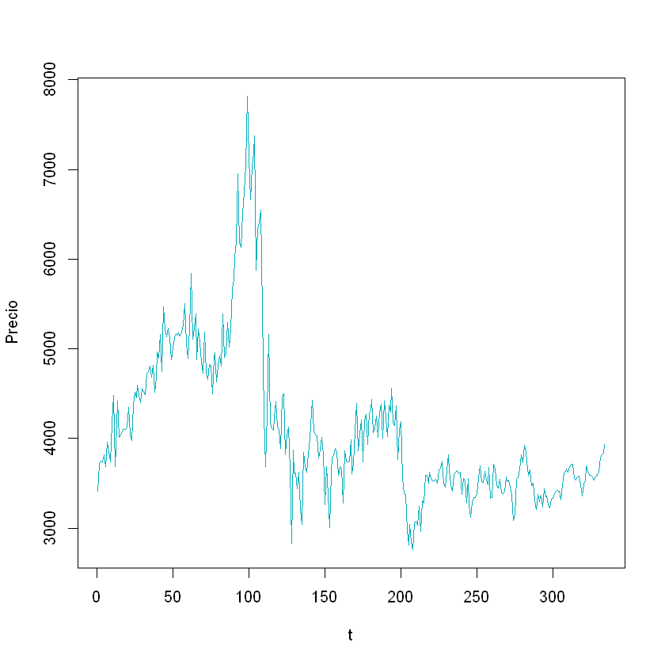

```r
#Graficamos los precios de las computadoras
plot(Precio,type="l",xlab="t",col="#00aebc")
```

```r
#Calculamos un AR(1)
Modelo_AR= ar.ols(Precio,aic=TRUE,order.max=1)
Modelo_AR
```

```
Call:
ar.ols(x = Precio, aic = TRUE, order.max = 1)

Coefficients:
     1
0.9411

Intercept: 1.603 (16.15)

Order selected 1  sigma^2 estimated as  86861
```

```r
#El modelo AR(1) de los precios es: Yt= intercepto + rho*Yt-1+epsilont

#Le damos el valor al intercepto del Modelo AR(1)
intercepto=Modelo_AR$x.intercept

#Le damos valor al coeficiente del Modelo AR(1)
rho=Modelo_AR$ar

#El numero de observaciones usadas para estimar el Modelo AR(1)
obs=Modelo_AR$n.obs

#Definimos a sigma del error como la desv estandar de los residuos
sigma=sd(Modelo_AR$resid[2:obs])
```

```r
#Funcion para simular el precio de computadoras
simular_AR1=function(intercept,rho_sim){
    epsilon_sim=rnorm(1,mean=0,sd=sigma) #Simulamos epsilon
    y=intercept+rho_sim*Precio[obs]+epsilon_sim

    return(y)
}

Precio_sim=simular_AR1(intercepto,rho)
Precio_sim
```

3680.48542380083

# SIMULACION DE VPNs DE DISTINTOS ESCENARIOS DEL PROYECTO

```r
#Vector vacio donde se van a guardar los VPNs
vec_vpn=rep(NaN,nSim)

#Vector vacio donde se van a guardar las diferentes inversiones iniciales
inv_inic= rep(NaN,nSim)
```

```r
#Para cada simulacion
for (t in 1:nSim){
    #Sabemos que nuestra inversion inicial estara entre 100,000 y 1,000,000
    inv_inic[t]=sample(100000:1000000,1) #Simulamos la inversion inicial
    #Vector vacio en donde se va a guardar cada cashflow por el numero de periodos nT
    vec_cashflow=rep(NaN,nT)
    #El primer elemento del cashflow va a ser la inversion inicial pero en negativo
    vec_cashflow[1]=-inv_inic[t]
    #La depreciacion es el 20% de la inversion (maquinaria que vamos a comprar)
    depreciacion=-vec_cashflow[1]*0.2
    #El impuesto
    ISR=0.25
    for (i in 2:nT){
        #Simulamos las siguientes variables:
        #Sabemos que la cantidad del producto a ofertar va a estar entre 1,000 y 700 unidades al año
        q=cantidad=sample(100:700,1)
        #Sabemos el rango de nuestro cambio en el capital de trabajo
        ckt=cambio_Ktrabajo=sample(-2000:2000,1)
        #Como no podemos definir nuestro precio de mercado, se simula el precio de mercado
        p=simular_AR1(intercepto,rho)
        #Sabemos que nuestro costo unitario de produccion es el 60% del precio
        cp=costo_unitario_prod=0.60*p
        #Sabemos que nuestro costo unitario de venta es el 25% del precio
        cv=costo_unitario_venta=0.25*p
        #Cada cashflow se agrega al vector de cash flows de nT periodos
        vec_cashflow[i]=cash_flow(q,p,cp,cv,ckt,ISR,depreciacion)
    }
    #Se calcula el VPN para cada vector de cashflows para 10,000 simulaciones
    vec_vpn[t]=npv(r=tasa_desc,cf=vec_cashflow)
}
```

284684.115506615

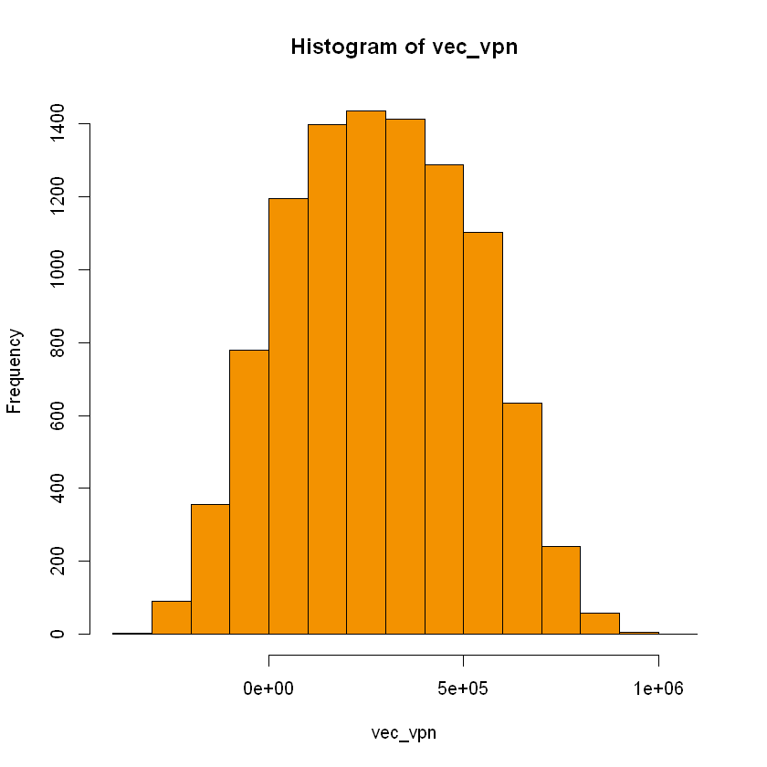

```r
#Media de VPNs
mean(vec_vpn)

#Graficamos la distribucion de los VPNs
hist(vec_vpn,col="#f39200")
```

```r
#Vector vacio donde se va a guardar 1 si el VPN es positivo y 0 si es negativo
vec_prob=rep(NaN,nSim)

#Funcion de probabilidad que el VPN sea menor a un numero
Menor = function(a){
    for (i in 1:nSim) {
        if (vec_vpn[i] < a)
            vec_prob[i]=1
        else
            vec_prob[i]=0
    }
    Probabilidad = sum(vec_prob)/nSim
    return(Probabilidad)
}

#La probabilidad que el VPN sea negativo
Menor(0)
```

0.1228

```r
#Funcion de probabilidad que el VPN sea mayor a un numero
Mayor = function(a){
    for (i in 1:nSim) {
        if (vec_vpn[i] > a)
            vec_prob[i]=1
        else
            vec_prob[i]=0
    }
    Probabilidad = sum(vec_prob)/nSim
    return(Probabilidad)
}

#La probabilidad que el VPN sea positivo
Mayor(0)

#La probabilidad que el VPN sea mayor a 500,000
Mayor(500000)
```

0.8772

0.2042

# EJEMPLO ANALISIS SENSIBILIDAD

# Variable: Precio del Producto

```r
vec_vpn2=rep(NaN,nSim) #Creamos un vector que va a guardar todos los VPN por cada simulacion

inv_ini2=-sample(50000:200000,1) #Esta es la inversion inicial
q2=sample(100:700,1)
p2=simular_AR1(intercepto,rho)
cp2=0.60*p2 #Costo unitario de producción FIJO
cv2=0.25*p2 #Costo unitario por venta FIJO
ckt2=sample(-2000:2000,1) #Cambio de capital trabajo FIJO
depreciacion2=-inv_ini2*0.2 #Esta es la depreciacion de la maquinaria que se va a comprar con la inversion inicial
ISR=0.25

vec_precio=rep(NaN,nSim)
```

```r
for (t in 1:nSim){
    vec_cashflow=rep(NaN,nT) #En este vector se guarda cada cashflow por la cantidad de periodos
    vec_cashflow[1]=-inv_ini2 #Valor inicial de la inversión
    vec_precio[t]=simular_AR1(intercepto,rho) #Vector de precios que se simulara para el analisis de sensibilidad

    for (i in 2:nT){

        #Agregamos al vector de cashflows el calculo del cashflow por cada periodo (nT)
        vec_cashflow[i]=cash_flow(q2,vec_precio[t],cp2,cv2,ckt2,ISR,depreciacion2)


    }
    #Agregamos al vector de VPNs el calculo del VPN por cada vector de cashflow
    vec_vpn2[t]=npv(r=tasa_desc,cf=vec_cashflow)

}
```

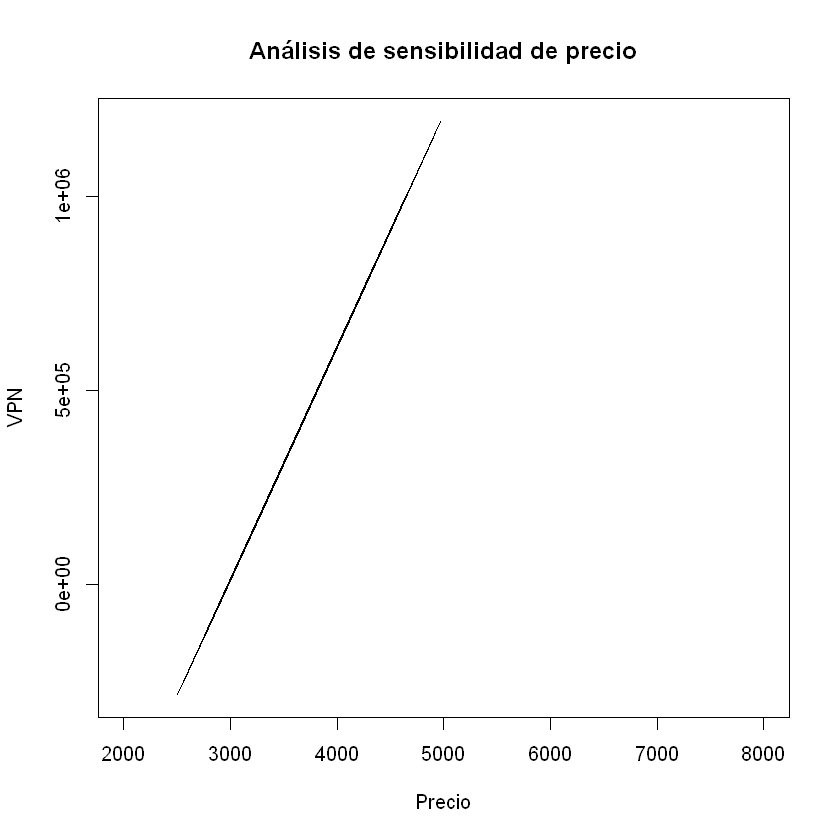

```r
# Gráficas de sensibilidad de precios
plot(vec_precio,vec_vpn2,type="l",xlim=c(2000,8000),xlab = "Precio",ylab="VPN", main = "Análisis de sensibilidad de precio")
```